# Dada2_Labus2017

# 1. IMPORT

```r
library(dada2)
packageVersion("dada2") # check dada2 version
```

```
## [1] '1.22.0'
```

```r
library(Biostrings)
library(ShortRead)
library(seqTools) # per base sequence content
library(phyloseq)
library(ggplot2)
library(data.table)
library(plyr)
library(dplyr)
library(qckitfastq) # per base sequence content
library(stringr)

# ROOT DIRECTORY (to modify on your computer)
path.root <- "~/Projects/MetaIBS"
path.labus  <- file.path(path.root, "scripts/analysis-individual/Labus-2017")
path.data   <- file.path(path.root, "data/analysis-individual/Labus-2017")
```

# 2. QUALITY CHECK

### 2.1. Fastq quality profiles

First, we import the fastq files containing the raw reads. The samples were downloaded from the ENA database with the accession number PRJNA373876.

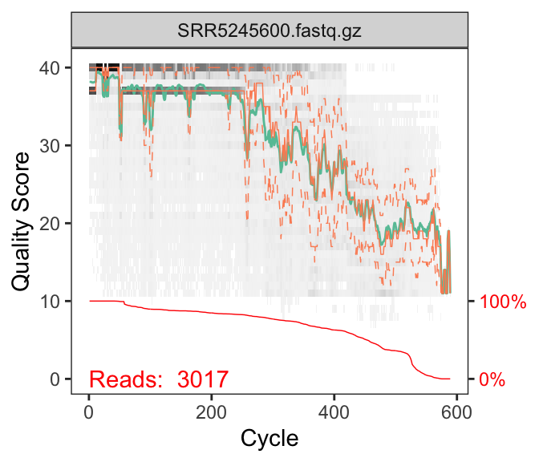

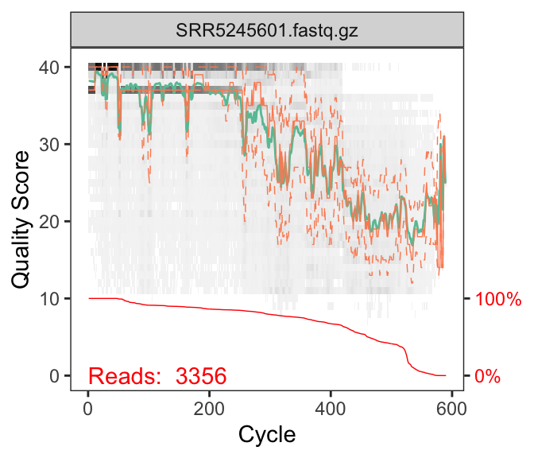

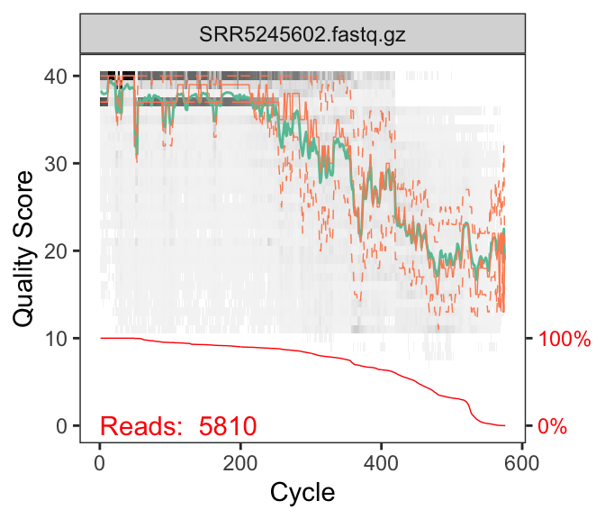

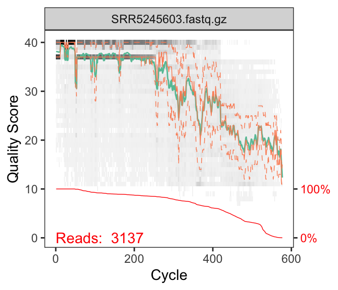

```r
# Save the path to the directory containing the fastq zipped files
path.fastq <- file.path(path.data, "raw_fastq")
# list.files(path.fastq) # check we are in the right directory

# fastq filenames have format: SAMPLENAME.fastq.gz
# Saves the whole directory path to each file name
FNs <- sort(list.files(path.fastq, pattern=".fastq.gz", full.names = TRUE))
show(FNs[1:5])

# Extract sample names, assuming filenames have format: SAMPLENAME.fastq.gz
sample.names <- sapply(strsplit(basename(FNs), ".fastq.gz"), `[`, 1)
show(sample.names[1:5]) # saves only the file name (without the path)

# Look at quality of all files
for (i in 1:4){ # 1:length(FNs)
  show(plotQualityProfile(FNs[i]))
}
```

```r
# Look at number of reads per sample
raw_stats <- data.frame('sample' = sample.names,
                        'reads' = fastqq(FNs)@nReads)
min(raw_stats$reads) # min 1,611 reads/sample
max(raw_stats$reads) # max 9,129 reads/sample
mean(raw_stats$reads) # average 3,526 reads/sample
```

We will have a quick peak at the per base sequence content of the reads in some samples, to make sure there is no anomaly (i.e. all reads having the same sequence).

```r
# Look at per base sequence content
fseq <- seqTools::fastqq(FNs[10])
```

```
## [fastqq] File ( 1/1) '/Users/enigma/Projects/MetaIBS/data/analysis-individual/Labus-2017/raw_fastq/SRR5245609.fastq.gz'  done.
```

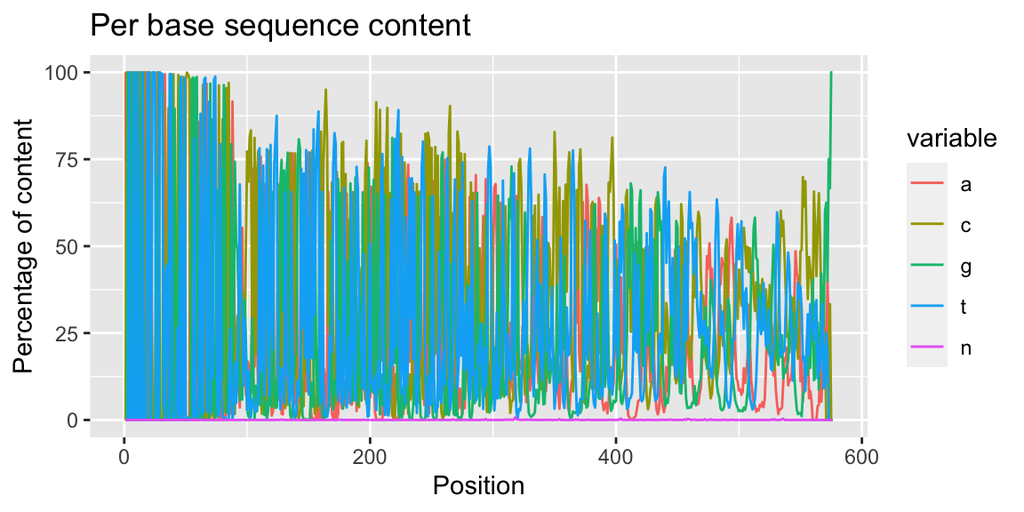

```r
rc <- read_content(fseq)
plot_read_content(rc) + labs(title = "Per base sequence content")
```

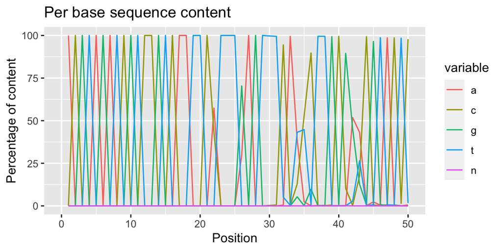

```r
plot_read_content(rc) + xlim(0,50) + labs(title = "Per base sequence content")
```

### 2.2. Look for primers

Now, we will look whether the reads still contain the primers. In the paper, they describe using V3-V5 primers, as in the article *Evaluation of 16S rDNA-based community profiling for human microbiome research* (Human Microbiome Project). Supplementary data in this article provides the primers sequences.

```r
# V3-V5
FWD <- "CCTACGGGAGGCAGCAG"  # 357F primer sequence (in reality, it's sequence 5'-341-357- 3')
REV <- "CCGTCAATTCMTTTRAGT" # 926R primer sequence

# Function that, from the primer sequence, will return all combinations possible (complement, reverse complement, ...)
allOrients <- function(primer) {
    require(Biostrings)
    dna <- DNAString(primer)  # The Biostrings works w/ DNAString objects rather than character vectors
    orients <- c(Forward = dna, Complement = complement(dna), Reverse = reverse(dna),
        RevComp = reverseComplement(dna))
    return(sapply(orients, toString))  # Convert back to character vector
}

# Get all combinations of the primer sequences
FWD.orients <- allOrients(FWD) # 357F
REV.orients <- allOrients(REV) # 926R
FWD.orients # sanity check
```

```
##             Forward          Complement             Reverse             RevComp
## "CCTACGGGAGGCAGCAG" "GGATGCCCTCCGTCGTC" "GACGACGGAGGGCATCC" "CTGCTGCCTCCCGTAGG"
```

```r
REV.orients
```

```
##              Forward           Complement              Reverse
## "CCGTCAATTCMTTTRAGT" "GGCAGTTAAGKAAAYTCA" "TGARTTTMCTTAACTGCC"
##              RevComp
## "ACTYAAAKGAATTGACGG"
```

```r
# Function that counts number of reads containing a sequence
primerHits <- function(primer, fn) {
    nhits <- vcountPattern(primer, sread(readFastq(fn)), fixed = FALSE, max.mismatch = 2)
    return(sum(nhits > 0))
}

# Look in all samples if we find the primers
for (i in 1:5){
  cat("SAMPLE", sample.names[i], "with total number of", raw_stats[i,'reads'], "reads\n\n")
  # Get a table to know how many times the 357F and 926R primers are found (in how many reads)
  x <-  rbind(ForwardPrimer = sapply(FWD.orients, primerHits, fn = FNs[[i]]),
              ReversePrimer = sapply(REV.orients, primerHits, fn = FNs[[i]]))
  print(x)
  cat("\n____________________________________________\n\n")
}
```

```
## SAMPLE SRR5245600 with total number of 3017 reads
##
##               Forward Complement Reverse RevComp
## ForwardPrimer       0          0       0     118
## ReversePrimer    3017          0       0       0
##
## ____________________________________________
##
## SAMPLE SRR5245601 with total number of 3356 reads
##
##               Forward Complement Reverse RevComp
## ForwardPrimer       0          0       0      75
## ReversePrimer    3356          0       0       0
##
## ____________________________________________
##
## SAMPLE SRR5245602 with total number of 5810 reads
##
##               Forward Complement Reverse RevComp
## ForwardPrimer       0          0       0      12
## ReversePrimer    5810          0       0       0
##
## ____________________________________________
##
## SAMPLE SRR5245603 with total number of 3137 reads
##
##               Forward Complement Reverse RevComp
## ForwardPrimer       0          0       0      11
## ReversePrimer    3137          0       0       0
##
## ____________________________________________
##
## SAMPLE SRR5245604 with total number of 4971 reads
##
##               Forward Complement Reverse RevComp
## ForwardPrimer       0          0       0       3
## ReversePrimer    4971          0       0       0
##
## ____________________________________________
```

Let’s have a quick look at where primers are positioned in the reads

```r
# Function that gets position in which sequence is found
primerHitsPosition <- function(primer, fn){
  hits <- as.data.frame(vmatchPattern(primer, sread(readFastq(fn)), fixed = FALSE, max.mismatch = 2))
  hits <- hits[,c("group", "start")]
  colnames(hits) <- c("sample", "start")
  hits$sample <- sapply(strsplit(basename(fn), "_"), `[`, 1)
  hits$readslength <- seqTools::fastqq(fn)@maxSeqLen
  return(hits)
}

# Get position of FWD primers
FWDpos <- data.frame()
for(i in 1:5){ # length(FNs)
  cat("SAMPLE", i)
  new <- primerHitsPosition(FWD.orients["RevComp"], FNs[[i]])
  FWDpos <- rbind(new, FWDpos)
}
```

```
## SAMPLE 1[fastqq] File ( 1/1) '/Users/enigma/Projects/MetaIBS/data/analysis-individual/Labus-2017/raw_fastq/SRR5245600.fastq.gz'  done.
## SAMPLE 2[fastqq] File ( 1/1) '/Users/enigma/Projects/MetaIBS/data/analysis-individual/Labus-2017/raw_fastq/SRR5245601.fastq.gz'  done.
## SAMPLE 3[fastqq] File ( 1/1) '/Users/enigma/Projects/MetaIBS/data/analysis-individual/Labus-2017/raw_fastq/SRR5245602.fastq.gz'  done.
## SAMPLE 4[fastqq] File ( 1/1) '/Users/enigma/Projects/MetaIBS/data/analysis-individual/Labus-2017/raw_fastq/SRR5245603.fastq.gz'  done.
## SAMPLE 5[fastqq] File ( 1/1) '/Users/enigma/Projects/MetaIBS/data/analysis-individual/Labus-2017/raw_fastq/SRR5245604.fastq.gz'  done.
```

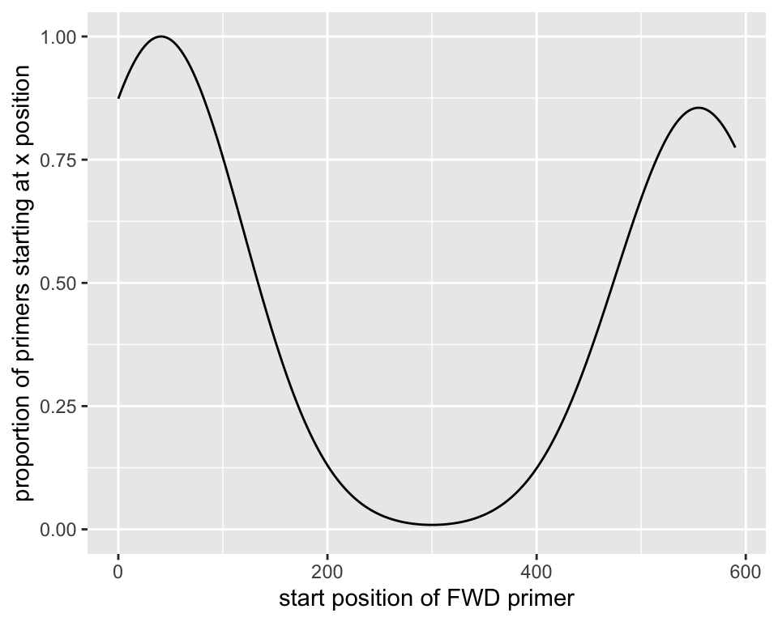

```r
ggplot(FWDpos, aes(x=start))+
  geom_density(aes(y=..scaled..)) +
  xlim(c(0,max(FWDpos$readslength)))+
  labs(x="start position of FWD primer", y="proportion of primers starting at x position")
```

```r
# Get position of REV primers
REVpos <- data.frame()
for(i in 1:5){ # length(FNs)
  cat("SAMPLE", i)
  new <- primerHitsPosition(REV.orients["Forward"], FNs[[i]])
  REVpos <- rbind(new, REVpos)
}
```

```
## SAMPLE 1[fastqq] File ( 1/1) '/Users/enigma/Projects/MetaIBS/data/analysis-individual/Labus-2017/raw_fastq/SRR5245600.fastq.gz'  done.
## SAMPLE 2[fastqq] File ( 1/1) '/Users/enigma/Projects/MetaIBS/data/analysis-individual/Labus-2017/raw_fastq/SRR5245601.fastq.gz'  done.
## SAMPLE 3[fastqq] File ( 1/1) '/Users/enigma/Projects/MetaIBS/data/analysis-individual/Labus-2017/raw_fastq/SRR5245602.fastq.gz'  done.
## SAMPLE 4[fastqq] File ( 1/1) '/Users/enigma/Projects/MetaIBS/data/analysis-individual/Labus-2017/raw_fastq/SRR5245603.fastq.gz'  done.
## SAMPLE 5[fastqq] File ( 1/1) '/Users/enigma/Projects/MetaIBS/data/analysis-individual/Labus-2017/raw_fastq/SRR5245604.fastq.gz'  done.
```

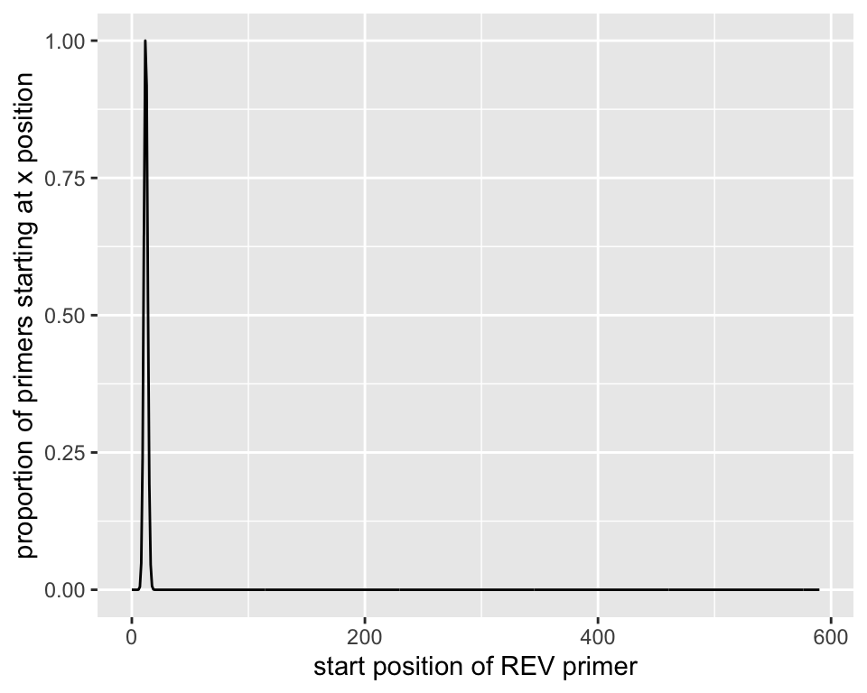

```r
ggplot(REVpos, aes(x=start))+
  geom_density(aes(y=..scaled..)) +
  xlim(c(0,max(REVpos$readslength)))+
  labs(x="start position of REV primer", y="proportion of primers starting at x position")
```

# 3. FILTER AND TRIM

### 3.1. Primer removal

The reads indeed contain the reverse primer at the start of the reads. We will keep only reads containing the primer, and then remove the primer!

```r
# KEEP READS WITH PRIMER AND REMOVE PRIMER
# Place filtered files in a filtered/ subdirectory
filt1_samples <- file.path(path.data, "filtered1", paste0(sample.names, "_filt.fastq.gz"))
# Assign names for the filtered fastq.gz files
names(filt1_samples) <- sample.names

# Filter first to take out primer
out1 <- removePrimers(fn = FNs, fout = filt1_samples,
                      primer.fwd = REV.orients['Forward'], # reverse primer is found at the beginning of the reads
                      trim.fwd = TRUE,
                      orient = FALSE, # keep the reads in their original orientation
                      compress = TRUE, verbose = TRUE)
```

```r
# Primer removal
out1[1:4,]
```

```
##                     reads.in reads.out
## SRR5245600.fastq.gz     3017      3017
## SRR5245601.fastq.gz     3356      3356
## SRR5245602.fastq.gz     5810      5810
## SRR5245603.fastq.gz     3137      3137
```

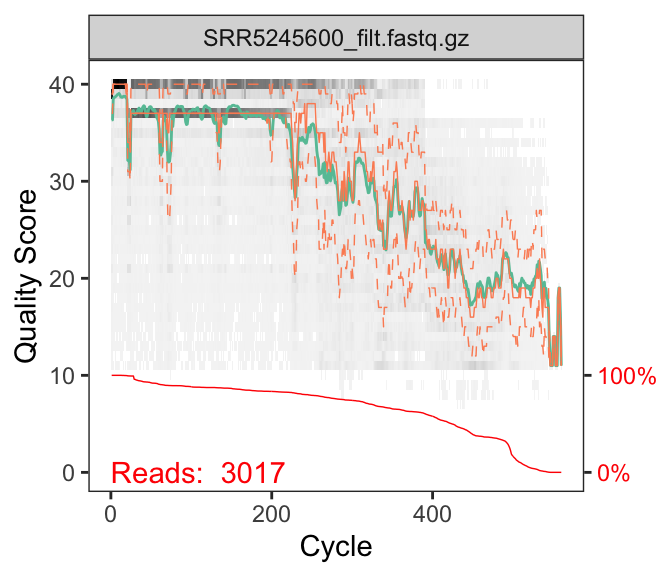

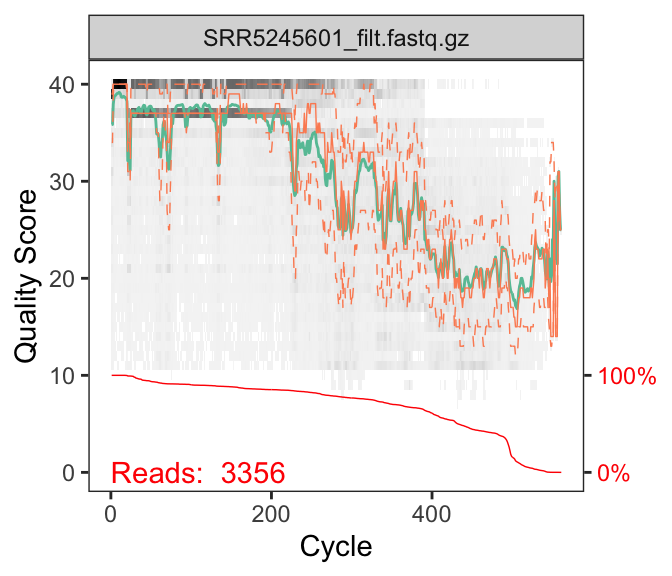

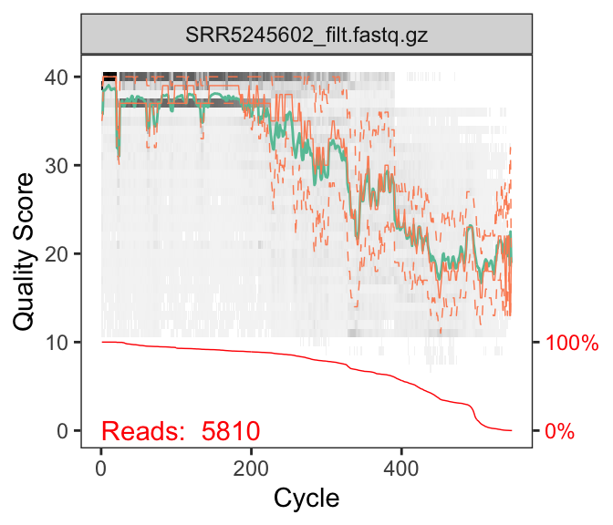

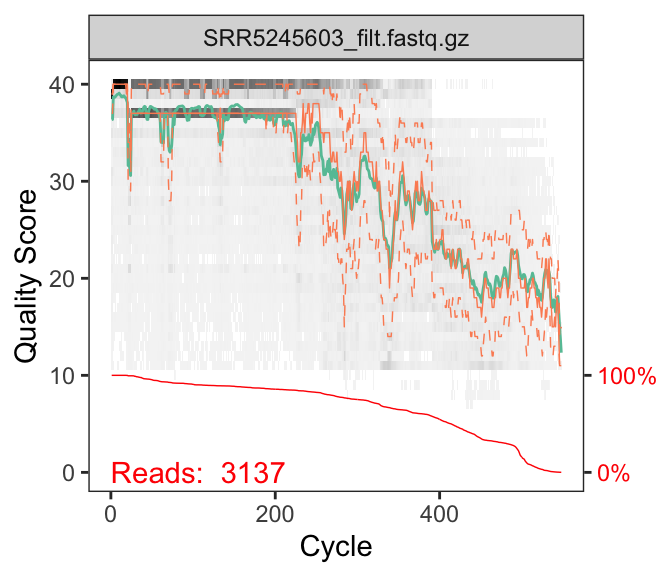

```r
# Quality profile after primer removal
for (i in 1:4){
  show(plotQualityProfile(filt1_samples[i]))
}
```

### 3.2. Quality filtering

Then, we perform a quality filtering of the reads.

```r
# Place filtered files in a filtered/ subdirectory
filt2_samples <- file.path(path.data, "filtered2", paste0(sample.names, "_filt.fastq.gz"))
# Assign names for the filtered fastq.gz files
names(filt2_samples) <- sample.names

# Filter
out2 <- filterAndTrim(fwd = filt1_samples, filt = filt2_samples,
                      maxEE=3, # reads with more than 3 expected errors (sum(10e(-Q/10))) are discarded
                      truncQ=10, # Truncate reads at the first instance of a quality score less than or equal to truncQ.
                      minLen=150, # Discard reads shorter than 150 bp. This is done after trimming and truncation.
                      compress=TRUE,
                      multithread=TRUE,
                      verbose=TRUE)
```

Let’s look at the output filtered fastq files as sanity check.

```r
out2[1:4,] # show how many reads were filtered in each file
```

```
##                          reads.in reads.out
## SRR5245600_filt.fastq.gz     3017      2090
## SRR5245601_filt.fastq.gz     3356      2445
## SRR5245602_filt.fastq.gz     5810      4405
## SRR5245603_filt.fastq.gz     3137      2328
```

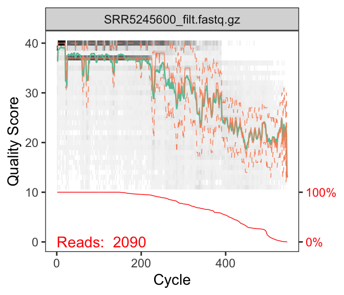

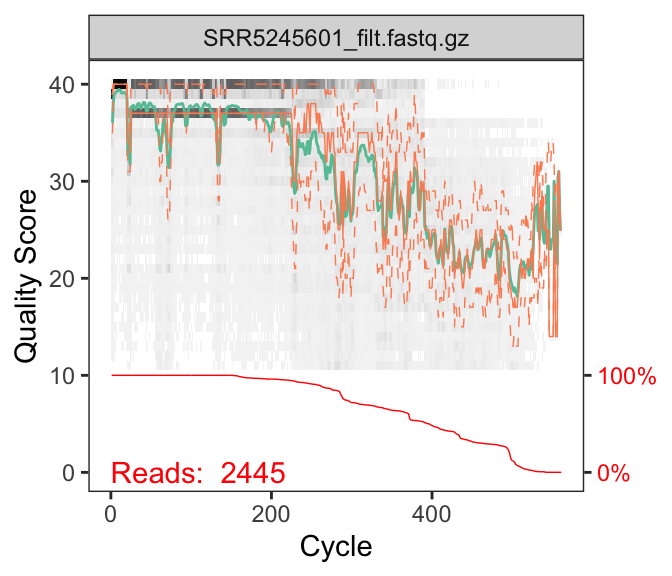

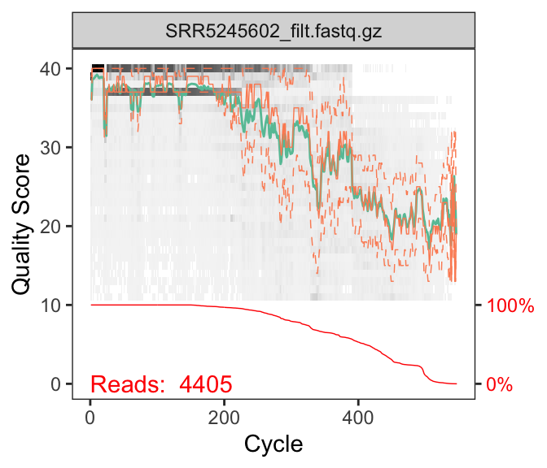

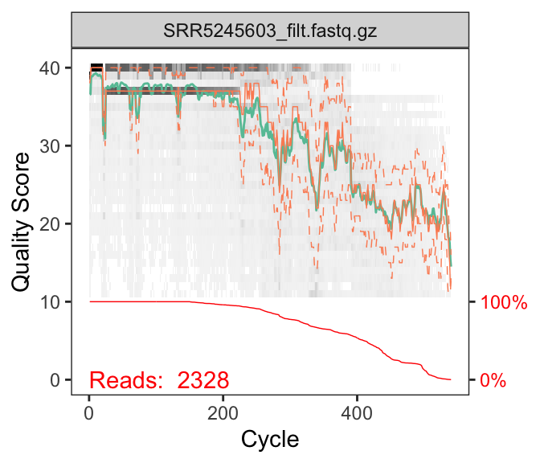

```r
# Look at quality profile of filtered files
for (i in 1:4){
  show(plotQualityProfile(filt2_samples[i]))
}
```

# 4. CONSTRUCT ASV TABLE

### 4.1. Learn error rates

Now we will build the parametric error model, to be able to infer amplicon sequence variants (ASVs) later on.

```r
set.seed(123)
err <- learnErrors(filt2_samples, multithread=TRUE, randomize = TRUE, verbose = 1)
```

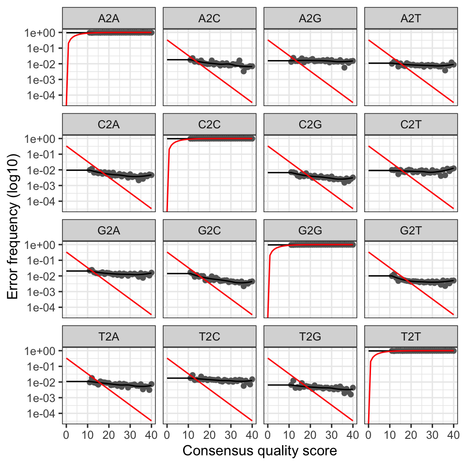

```r
plotErrors(err, nominalQ = TRUE)
```

### 4.2. Infer sample composition

The *dada()* algorithm infers sequence variants based on estimated errors (previous step). Firstly, we de-replicate the reads in each sample, to reduce the computation time. De-replication is a common step in almost all modern ASV inference (or OTU picking) pipelines, but a unique feature of derepFastq is that it maintains a summary of the quality information for each dereplicated sequence in $quals.

```r
# Prepare empty vector for the infered sequences
seq_infered <- vector("list", length(sample.names))
names(seq_infered) <- sample.names

# Iterate through the 52 samples
for(sampl in sample.names) {
  cat("Processing:", sampl, "\n")
  derep <- derepFastq(filt2_samples[[sampl]]) # dereplicate the reads in the sample
  seq_infered[[sampl]] <- dada(derep, err=err, multithread=TRUE, # default parameters
                               HOMOPOLYMER_GAP_PENALTY=-1, BAND_SIZE=32) # recommended parameters for 454 sequencing
}
```

```r
# Inspect the infered sequence variants from sample 1:5
for (i in 1:5){
  print(seq_infered[[i]])
  print("________________")
}
```

```
## dada-class: object describing DADA2 denoising results
## 24 sequence variants were inferred from 1918 input unique sequences.
## Key parameters: OMEGA_A = 1e-40, OMEGA_C = 1e-40, BAND_SIZE = 32
## [1] "________________"
## dada-class: object describing DADA2 denoising results
## 23 sequence variants were inferred from 2138 input unique sequences.
## Key parameters: OMEGA_A = 1e-40, OMEGA_C = 1e-40, BAND_SIZE = 32
## [1] "________________"
## dada-class: object describing DADA2 denoising results
## 28 sequence variants were inferred from 3818 input unique sequences.
## Key parameters: OMEGA_A = 1e-40, OMEGA_C = 1e-40, BAND_SIZE = 32
## [1] "________________"
## dada-class: object describing DADA2 denoising results
## 23 sequence variants were inferred from 2148 input unique sequences.
## Key parameters: OMEGA_A = 1e-40, OMEGA_C = 1e-40, BAND_SIZE = 32
## [1] "________________"
## dada-class: object describing DADA2 denoising results
## 26 sequence variants were inferred from 3573 input unique sequences.
## Key parameters: OMEGA_A = 1e-40, OMEGA_C = 1e-40, BAND_SIZE = 32
## [1] "________________"
```

### 4.3. Construct ASV table

We can now construct an amplicon sequence variant table (ASV) table, a higher-resolution version of the OTU table produced by traditional methods.

```r
# Make sequence table from the infered sequence variants
seqtable <- makeSequenceTable(seq_infered)

# We should have 52 samples (52 rows)
dim(seqtable)
```

```
## [1]  52 726
```

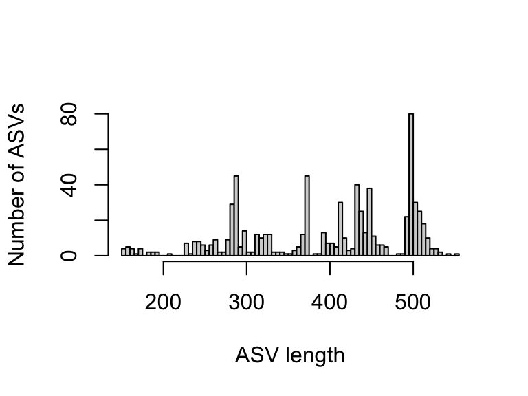

```r
# Inspect distribution of ASVs lengths
hist(nchar(getSequences(seqtable)), breaks = 100, xlab = "ASV length", ylab = "Number of ASVs", main="")
```

### 4.4. Remove chimeras

The core dada method corrects substitution and indel errors, but chimeras remain. Fortunately, the accuracy of sequence variants after denoising makes identifying chimeric ASVs simpler than when dealing with fuzzy OTUs. Chimeric sequences are identified if they can be exactly reconstructed by combining a left-segment and a right-segment from two more abundant “parent” sequences.

```r
seqtable.nochim <- removeBimeraDenovo(seqtable, method="consensus", multithread=TRUE, verbose=TRUE)

# Check how many sequence variants we have after removing chimeras
dim(seqtable.nochim)
```

```
## [1]  52 710
```

```r
# Check how many reads we have after removing chimeras (we should keep the vast majority of the reads)
sum(seqtable.nochim)/sum(seqtable)
```

```
## [1] 0.9961412
```

# 5. LOOK AT READS COUNT THROUGH PIPELINE

Sanity check before assigning taxonomy.

```r
# Function that counts nb of reads
getN <- function(x) sum(getUniques(x))

# Table that will count number of reads for each process of interest (input reads, filtered reads, denoised reads, non chimera reads)
track <- cbind(out1,
               out2[,2],
               sapply(seq_infered, getN),
               rowSums(seqtable.nochim),
               lapply(rowSums(seqtable.nochim)*100/out1[,1], as.integer))

# Assign column and row names
colnames(track) <- c("input", "primer-filt", "quality-filt", "denoised", "nonchim", "%input->output")
rownames(track) <- sample.names

# Show final table
track
```

```
##            input primer-filt quality-filt denoised nonchim %input->output
## SRR5245600 3017  3017        2090         1651     1651    54
## SRR5245601 3356  3356        2445         2121     2074    61
## SRR5245602 5810  5810        4405         4096     4094    70
## SRR5245603 3137  3137        2328         2093     2093    66
## SRR5245604 4971  4971        3909         3510     3510    70
## SRR5245605 9129  9129        7465         7216     7216    79
## SRR5245606 4090  4090        3065         2628     2623    64
## SRR5245607 5564  5564        4240         3735     3735    67
## SRR5245608 3942  3942        3031         2666     2666    67
## SRR5245609 2799  2799        2132         1846     1846    65
## SRR5245610 3409  3409        2508         1990     1990    58
## SRR5245611 4711  4711        3608         3151     3151    66
## SRR5245612 2941  2941        2084         1572     1568    53
## SRR5245613 2527  2527        1907         1595     1595    63
## SRR5245614 2352  2352        1788         1646     1646    69
## SRR5245615 3932  3932        2875         2493     2493    63
## SRR5245616 3848  3848        2897         2441     2441    63
## SRR5245617 5549  5549        4180         3946     3946    71
## SRR5245618 5130  5130        3902         3682     3682    71
## SRR5245619 2976  2976        2253         1872     1864    62
## SRR5245620 3350  3350        2492         2198     2147    64
## SRR5245621 3424  3424        2493         2219     2198    64
## SRR5245622 3223  3223        2282         2008     2008    62
## SRR5245623 3213  3213        2462         2164     2164    67
## SRR5245624 4623  4623        3426         3158     2980    64
## SRR5245625 4084  4084        3166         2660     2646    64
## SRR5245626 2924  2924        2163         1798     1789    61
## SRR5245627 2526  2526        1874         1508     1484    58
## SRR5245628 4237  4237        3125         2788     2788    65
## SRR5245629 2183  2183        1629         1059     1059    48
## SRR5245630 2205  2205        1745         1388     1388    62
## SRR5245631 3615  3615        2632         2293     2271    62
## SRR5245632 3718  3718        2695         2258     2258    60
## SRR5245633 2751  2751        2018         1592     1592    57
## SRR5245634 3075  3075        2301         1926     1890    61
## SRR5245635 2934  2934        2167         1727     1727    58
## SRR5245636 5402  5402        4205         3881     3881    71
## SRR5245637 3094  3094        2347         1817     1817    58
## SRR5245638 5181  5181        4004         3492     3492    67
## SRR5245639 2100  2100        1400         1132     1132    53
## SRR5245640 2140  2140        1401         882      882     41
## SRR5245641 1672  1672        1049         878      878     52
## SRR5245642 2807  2807        1851         1569     1569    55
## SRR5245643 2796  2796        1953         1875     1875    67
## SRR5245644 2182  2182        1492         1069     1069    48
## SRR5245645 1875  1875        1189         769      769     41
## SRR5245646 1921  1921        1387         1067     1067    55
## SRR5245647 4530  4530        3392         3006     3006    66
## SRR5245648 1858  1858        1177         786      786     42
## SRR5245649 4438  4438        3329         2821     2821    63
## SRR5245650 1611  1611        1043         678      678     42
## SRR5245651 4474  4474        3454         2977     2945    65
```

```r
# Save nb of reads per sample before / after dada2 pipeline
nb.reads <- data.frame("after"=rowSums(seqtable.nochim)) %>%
  mutate("Run"=names(rowSums(seqtable.nochim))) %>%
  right_join(raw_stats %>% dplyr::rename(Run=sample, before=reads),
             by="Run") %>%
  relocate(before) %>%
  relocate(Run) %>%
  mutate(after = nafill(after, fill=0),
         "dataset" = "Labus")

# saveRDS(nb.reads, file.path(path.root, "data/analysis-combined/06_QCplot/nbreads_labus.rds"))
```

# 6. TAXONOMIC TABLE

Extensions: The dada2 package also implements a method to make species level assignments based on exact matching between ASVs and sequenced reference strains. Recent analysis suggests that exact matching (or 100% identity) is the only appropriate way to assign species to 16S gene fragments. Currently, species-assignment training fastas are available for the Silva and RDP 16S databases. To follow the optional species addition step, download the silva_species_assignment_v138.fa.gz file, and place it in the directory with the fastq files.

```r
path.silva <- file.path(path.root, "data/analysis-individual/CLUSTER/taxonomy/silva-taxonomic-ref")

# Assign taxonomy (with silva v138)
set.seed(123)
taxa <- assignTaxonomy(seqtable.nochim, file.path(path.silva, "silva_nr99_v138.1_train_set.fa.gz"),
                       tryRC = TRUE, # try reverse complement of the sequences
                       multithread=TRUE, verbose = TRUE)

# Add species assignment
set.seed(123)
taxa <- addSpecies(taxa, file.path(path.silva, "silva_species_assignment_v138.1.fa.gz"))
```

```r
# Check how the taxonomy table looks like
taxa.print <- taxa
rownames(taxa.print) <- NULL # Removing sequence rownames for display only
head(taxa.print)
```

```
##      Kingdom    Phylum         Class           Order
## [1,] "Bacteria" "Bacteroidota" "Bacteroidia"   "Bacteroidales"
## [2,] "Bacteria" "Bacteroidota" "Bacteroidia"   "Bacteroidales"
## [3,] "Bacteria" "Firmicutes"   "Clostridia"    "Oscillospirales"
## [4,] "Bacteria" "Bacteroidota" "Bacteroidia"   "Bacteroidales"
## [5,] "Bacteria" "Firmicutes"   "Clostridia"    "Lachnospirales"
## [6,] "Bacteria" "Firmicutes"   "Negativicutes" "Veillonellales-Selenomonadales"
##      Family            Genus              Species
## [1,] "Bacteroidaceae"  "Bacteroides"      NA
## [2,] "Bacteroidaceae"  "Bacteroides"      NA
## [3,] "Ruminococcaceae" "Faecalibacterium" NA
## [4,] "Bacteroidaceae"  "Bacteroides"      NA
## [5,] "Lachnospiraceae" "Blautia"          NA
## [6,] "Veillonellaceae" "Dialister"        NA
```

```r
table(taxa.print[,1]) # Show the different kingdoms (should be only bacteria)
```

```
##
## Bacteria
##      710
```

```r
table(taxa.print[,2]) # Show the different phyla
```

```
##
## Actinobacteriota     Bacteroidota    Cyanobacteria       Firmicutes
##               22              169                3              500
##   Proteobacteria     Synergistota
##               13                1
```

```r
table(is.na(taxa.print[,2])) # is there any NA phyla?
```

```
##
## FALSE  TRUE
##   708     2
```

# 7. LAST PREPROCESSING

We will remove any sample with less than 500 reads from further analysis, and also any ASVs with unassigned phyla.

### 7.1. Create phyloseq object

The preprocessing will be easier to do with ASV, taxonomic and metadata tables combined in a phyloseq object.

```r
#_________________________
# Import metadata
sampledf <- read.csv(file.path(path.data, "00_Metadata-Labus/Metadata-Labus.csv"), row.names=1)


#_________________________
# Create phyloseq object
physeq <- phyloseq(otu_table(seqtable.nochim, taxa_are_rows=FALSE), # by default, in otu_table the sequence variants are in rows
                  sample_data(sampledf),
                  tax_table(taxa))

# Remove taxa that are eukaryota, or have unassigned Phyla
physeq <- subset_taxa(physeq, Kingdom != "Eukaryota")
physeq <- subset_taxa(physeq, !is.na(Phylum))
# Remove samples with less than 500 reads
physeq <- prune_samples(sample_sums(physeq)>=500, physeq)
# Some taxa might have been present only in these low-count samples, so we will make sure to remove taxa that are absent in all samples
physeq <- prune_taxa(taxa_sums(physeq)>0, physeq)
```

### 7.2. Quick peek at data analysis

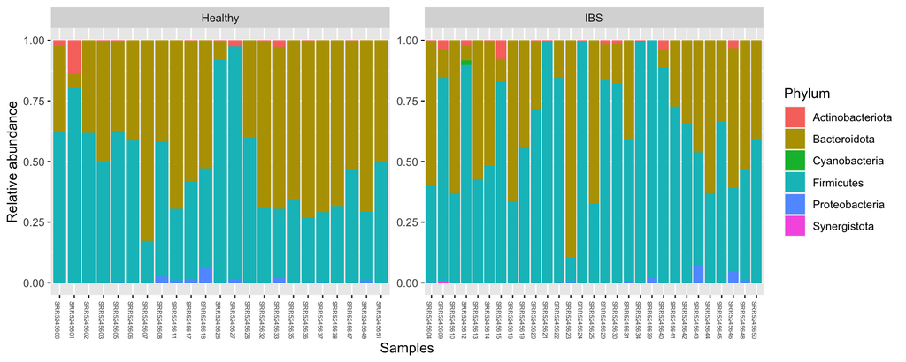

```r
# Absolute abundance
# plot_bar(physeq, fill = "Phylum")+ facet_wrap("host_disease", scales="free_x") + theme(axis.text.x = element_blank())

# Relative abundance for Phylum
phylum.table <- physeq %>%
  tax_glom(taxrank = "Phylum") %>%                     # agglomerate at phylum level
  transform_sample_counts(function(x) {x/sum(x)} ) %>% # Transform to rel. abundance
  psmelt()                                             # Melt to long format

ggplot(phylum.table, aes(x = Sample, y = Abundance, fill = Phylum))+
  facet_wrap(~ host_disease, scales = "free") + # scales = "free" removes empty lines
  geom_bar(stat = "identity") +
  theme(axis.text.x = element_text(size = 5, angle = -90))+
  labs(x = "Samples", y = "Relative abundance")
```

### 7.3. Save to disk

```r
# Save to disk
saveRDS(raw_stats,   file.path(path.data, "01_Dada2-Labus/raw_stats.rds"))
saveRDS(out1,        file.path(path.data, "01_Dada2-Labus/out1.rds"))
saveRDS(out2,        file.path(path.data, "01_Dada2-Labus/out2.rds"))
saveRDS(err,         file.path(path.data, "01_Dada2-Labus/err.rds"))
saveRDS(seq_infered, file.path(path.data, "01_Dada2-Labus/seq_infered.rds"))

# Taxa & Phyloseq object
saveRDS(taxa,   file.path(path.data, "01_Dada2-Labus/taxa_labus.rds"))
saveRDS(physeq, file.path(path.root, "data/analysis-individual/CLUSTER/phylotree/input/physeq_labus.rds"))
saveRDS(physeq, file.path(path.root, "data/phyloseq-objects/phyloseq-without-phylotree/physeq_labus.rds"))
```